# CISME Data Output

File: b3.com_May27_0952

## Meta Data

The is the meta data extracted from your original CISME file. It will also include any updated parameters from the user.

| Object | Value |
| --- | --- |
| Filename | /msc/Data/b3.com_May27_0952.csv |
| pH Slope(m) | 0.05876 |
| pH Eo (b) | -0.35526 |
| cal. Buffer pH | 8.10500 |
| cal. Buffer temp | 22.96982 |
| Salinity_edit | NA |
| Salinity | 35 |
| O2 0 Phase | 59.99000 |
| O2 0 Temp | 20.00000 |
| O2 100 Phase | 27.44000 |
| O2 100 Temp | 23.20000 |
| O2 LED Current | 150.00000 |
| O2 Pressure Cal | 1013.00000 |
| Total number of steps | 2 |
| Actual Run Time | 178.9998 |
| Step Number | 1 |
| Time Threshold | 180 |
| O2 Threshold | 0 |
| pH Threshold | 0.000 |
| Flow Rate | 5000.000000 |
| Actual Run Time | 238.9998 |
| Light Level | 0.000000 |
| Step Number | 2 |
| Time Threshold | 240 |
| O2 Threshold | 0 |
| pH Threshold | 0.000 |
| Flow Rate | 5000.000000 |
| Light Level | 18.000000 |
| Initial Total Alkalinity (umol/kg) | NA |
| Final Total Alkalinity (umol/kg) | NA |
| Surface Area (cm2) / Biomass (g) | 24.5 |
| Water Volume (L) | 0.088 |

## Calculated Parameters

### Corrected pH, corrected O<sub>2</sub>, scaled temperature, ln (O<sub>2</sub>)

First 5 rows of analyzed dark and light data

|  | Step No. | Total T(m) | Time(m) | O2 percent Sat. | O2 (umol/kg) | ISFET pH | ISFET Temp | ln (O2) | corrected O2 (uMol/kg) |
| --- | --- | --- | --- | --- | --- | --- | --- | --- | --- |
| 1 | 1 | 0.03333 | 0.03333 | 99.55 | 197.76 | 7.994213 | 27.44193 | 5.29 | 197.76 |
| 2 | 1 | 0.05000 | 0.05000 | 99.36 | 197.39 | 7.994940 | 27.44169 | 5.29 | 197.39 |
| 3 | 1 | 0.06667 | 0.06667 | 99.36 | 197.39 | 7.994805 | 27.44142 | 5.29 | 197.39 |
| 4 | 1 | 0.08333 | 0.08333 | 99.36 | 197.39 | 7.994530 | 27.44122 | 5.29 | 197.39 |
| 5 | 1 | 0.10000 | 0.10000 | 99.46 | 197.58 | 7.994322 | 27.44104 | 5.29 | 197.59 |
| 180 | 2 | 2.98333 | 0.00000 | 101.50 | 201.67 | 7.986212 | 27.42884 | 5.29 | 201.68 |
| 181 | 2 | 3.00000 | 0.01667 | 101.40 | 201.48 | 7.985167 | 27.42908 | 5.29 | 201.48 |
| 182 | 2 | 3.01666 | 0.03333 | 101.59 | 201.86 | 7.984670 | 27.42903 | 5.29 | 201.86 |
| 183 | 2 | 3.03333 | 0.05000 | 101.59 | 201.86 | 7.984761 | 27.42958 | 5.29 | 201.85 |
| 184 | 2 | 3.05000 | 0.06667 | 101.59 | 201.86 | 7.984834 | 27.42950 | 5.29 | 201.85 |

### Total Alkalinity, TCO<sub>2</sub>, and calcification rate

**Units for the calculated parameters are as follows:**

- Total Alkalinity (uMol/Kg)
- TCO<sub>2</sub> (uMol/Kg; calculated using R package *seacarb*)
- calcification rate (nMol/cm<sup>2</sup>)

*No total alkalinity values (initial and final) were supplied so table was not constructed.*

## Run Summary Table

| Parameter | Initial Dark Value (Respiration) | Final Dark Value (Respiration) | Dark Delta (Respiration) | Initial Light Value (Photosynthesis) | Final Light Value (Photosynthesis) | Light Delta (Photosynthesis) | Overall Run Delta |
| --- | --- | --- | --- | --- | --- | --- | --- |
| Temperature | 27.440 | 27.428 | -0.012 | 27.429 | 27.499 | 0.070 | 0.059 |
| pH | 7.995 | 7.986 | -0.009 | 7.984 | 7.982 | -0.002 | -0.013 |

## Data Visualizations

### pH and % O2 saturation over time

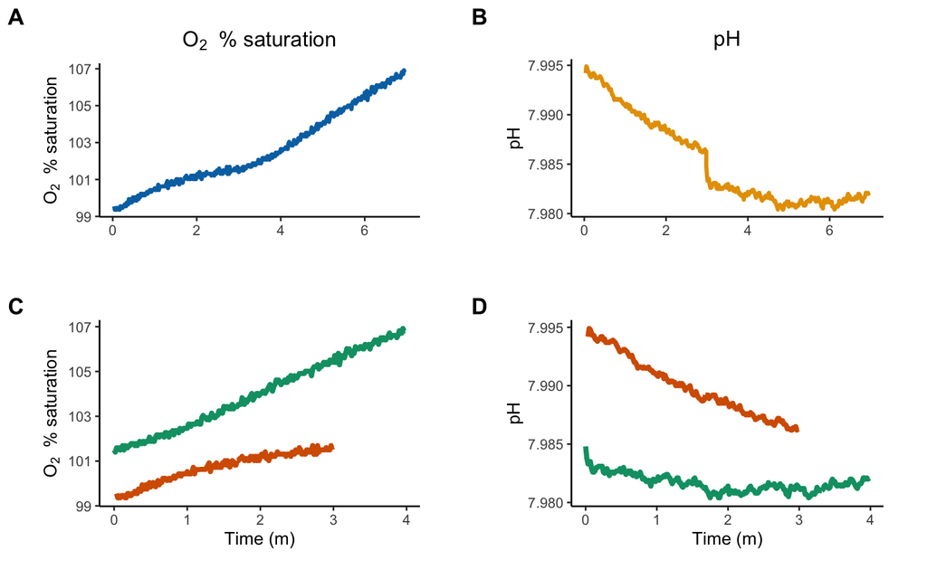

**Figure 1 |** Oxygen saturation (O<sub>2</sub> % Sat.) and pH measured in the experimental run. (**A**) The full O<sub>2</sub> % saturation (blue) and (**B**) pH (orange) throughout the duration of the experimental run. (**C**) O<sub>2</sub> and (**D**) pH are then separated out by light (green) and dark (red) components of the run (if applicable).

### Dark respiration rates

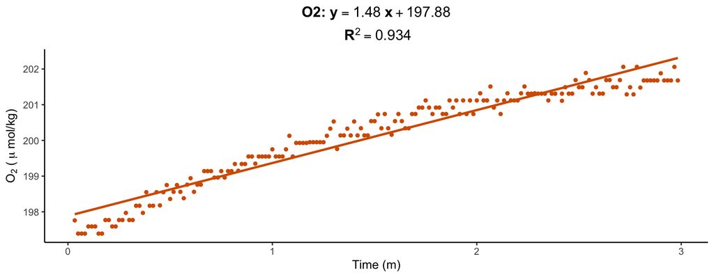

### Light photosynthesis rates

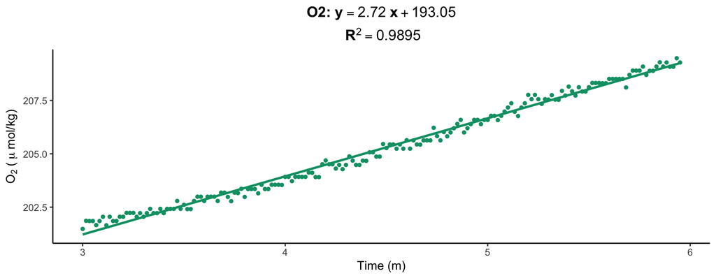

## Calculated Rates and Regression Equations

### Compiled table of O2 and TCO2 linear regression equations

| filename | parameter | light | slope | intercept | R2 | calculated rate (nMol/cm2/h) |
| --- | --- | --- | --- | --- | --- | --- |
| b3.com_May27_0952 | O2 | dark | 1.48 | 197.88 | 0.934 | 319.61 |
| b3.com_May27_0952 | O2 | light | 2.72 | 193.05 | 0.990 | 586.80 |

### Light calcification rate:

#### *No total alkalinity values (initial and final) were supplied so value was not calculated.*

## Questions?

#### If you have any questions about running this code, please contact Colleen Bove (colleenbove@gmail.com) for assistance.

This script for UNCW CISME Instruments was written by Colleen B. Bove.

### Session Information

*Script was last updated on 16 April 2022*